# Tugas Pertemuan 3

Fahmi Maulana Ardyansyah

2025-09-17

```r
#install.packages("dLagM")
library(dLagM)
library(dynlm)
#install.packages("MLmetrics")
library(MLmetrics)
library(lmtest)
library(car)
library(dplyr)
#input data
data <- read.csv("E:/(1) Projects/Semester 5/Metode Peramalan Deret Waktu/MPDW/Pertemuan-3/NewDelhi_Air_quality.csv")
str(data)
```

```
## 'data.frame':    72 obs. of  12 variables:
##  $ X              : int  0 1 2 3 4 5 6 7 8 9 ...
##  $ AQI            : num  30.2 28.2 26.6 25 26 26 26 24 23 24 ...
##  $ CO             : num  199 198 199 202 205 ...
##  $ datetime       : chr  "2022-10-21:18" "2022-10-21:19" "2022-10-21:20" "2022-10-21:21" ...
##  $ no2            : num  0.0469 0.0465 0.0469 0.0482 0.0489 ...
##  $ o3             : num  55.8 54.9 54.6 55.1 55.8 ...
##  $ pm10           : num  10.5 10.7 11.2 11.1 10.4 ...
##  $ pm25           : num  5.64 4.62 3.52 2.23 1.98 ...
##  $ so2            : num  0.387 0.41 0.402 0.376 0.339 ...
##  $ timestamp_local: chr  "2022-10-21T23:00:00" "2022-10-22T00:00:00" "2022-10-22T01:00:00" "2022-10-22T02:00:00" ...
##  $ timestamp_utc  : chr  "2022-10-21T18:00:00" "2022-10-21T19:00:00" "2022-10-21T20:00:00" "2022-10-21T21:00:00" ...
##  $ ts             : int  1666375200 1666378800 1666382400 1666386000 1666389600 1666393200 1666396800 1666400400 1666404000 1666407600 ...
```

```r
data
```

```
##     X  AQI       CO      datetime        no2       o3      pm10     pm25
## 1   0 30.2 198.6027 2022-10-21:18 0.04685717 55.78995 10.486722 5.637410
## 2   1 28.2 197.6013 2022-10-21:19 0.04645554 54.93164 10.719325 4.618169
## 3   2 26.6 198.6027 2022-10-21:20 0.04685717 54.64554 11.155578 3.520902
## 4   3 25.0 201.9405 2022-10-21:21 0.04819594 55.07469 11.116206 2.225919
## 5   4 26.0 205.2784 2022-10-21:22 0.04886533 55.78995 10.405250 1.979471
## 6   5 26.0 208.6163 2022-10-21:23 0.05020411 56.50520  9.402518 1.792677
## 7   6 26.0 208.6163 2022-10-22:00 0.05020411 55.78995  8.482822 1.752237
## 8   7 24.0 205.2784 2022-10-22:01 0.05020411 52.92892  7.586667 1.858459
## 9   8 23.0 200.2716 2022-10-22:02 0.04685717 50.06790  7.636587 2.208076
## 10  9 24.0 196.9338 2022-10-22:03 0.04417961 51.49841  8.487648 2.476681
## 11 10 25.0 198.6027 2022-10-22:04 0.04284084 53.64418  9.357371 2.585729
## 12 11 26.0 200.2716 2022-10-22:05 0.04049798 55.78995 10.338728 2.390081
## 13 12 27.0 203.6095 2022-10-22:06 0.04016329 59.36623 10.523314 2.086022
## 14 13 29.0 205.2784 2022-10-22:07 0.03882451 62.22725 10.635970 1.937047
```

[output cut: 131 more lines]

```r
# Pengubahan nama variabel agar mudah untuk diolah
names(data)[names(data) == "AQI"] <- "Yt"
names(data)[names(data) == "pm10"]  <- "Xt"

# Menambahkan kolom t untuk periodenya
data$t <- 1:nrow(data)

# Menambahkan kolom Y(t-1)
data[["Y(t-1)"]] <- dplyr::lag(data$Yt)

# Membuat data baru dengan menggunakan variabel pm25 saja sebagai peubah x sesuai dengan perintah soal
data <- data[, c("t", "Yt", "Y(t-1)", "Xt")]
print(data)
```

```
##     t   Yt Y(t-1)        Xt
## 1   1 30.2     NA 10.486722
## 2   2 28.2   30.2 10.719325
## 3   3 26.6   28.2 11.155578
## 4   4 25.0   26.6 11.116206
## 5   5 26.0   25.0 10.405250
## 6   6 26.0   26.0  9.402518
## 7   7 26.0   26.0  8.482822
## 8   8 24.0   26.0  7.586667
## 9   9 23.0   24.0  7.636587
## 10 10 24.0   23.0  8.487648
## 11 11 25.0   24.0  9.357371
## 12 12 26.0   25.0 10.338728
## 13 13 27.0   26.0 10.523314
## 14 14 29.0   27.0 10.635970
```

[output cut: 58 more lines]

## Pembagian Data

```r
#Split Data untuk data train (80%) dan data test (20%),
train<-data[1:58,]
test<-data[59:72,]
```

```r
#data time series
train.ts<-ts(train)
test.ts<-ts(test)
data.ts<-ts(data)
```

- **distributed lag model** : Variabel Dependen Y dipengaruhi oleh lag dari variabel independen X ( Xt-1, Xt-2 , dst)
- **Autoregresive model** : Variabel Dependen Y dipengaruhi oleh lag dirinya sendiri (Yt-1, Yt-2, dst) dan X sekarang (Xt)

# Model Koyck

Model Koyck didasarkan pada asumsi bahwa semakin jauh jarak lag peubah independen dari periode sekarang maka semakin kecil pengaruh peubah lag terhadap peubah dependen.

Koyck mengusulkan suatu metode untuk menduga model dinamis distributed lag dengan mengasumsikan bahwa semua koefisien $\beta$ mempunyai tanda sama.

Model kyock merupakan jenis paling umum dari model infinite distributed lag dan juga dikenal sebagai geometric lag

$$y_t=a(1-\lambda)+\beta_0X_t+\beta_1Z_t+\lambda Y_{t-1}+V_t$$

dengan
$$V_t=u_t-\lambda
u_{t-1}$$

## Pemodelan

Pemodelan model Koyck dengan `R` dapat menggunakan `dLagM::koyckDlm()` . Fungsi umum dari `koyckDlm` adalah sebagai berikut.

```r
# koyckDlm(x , y , intercept)
```

Fungsi `koyckDlm()` akan menerapkan model lag terdistribusi dengan transformasi Koyck satu prediktor. Nilai `x` dan `y` tidak perlu sebagai objek *time series* (`ts`). `intercept` dapat dibuat `TRUE` untuk memasukkan intersep ke dalam model.

```r
#MODEL KOYCK menggunakan fungsi koyckDlm()
model.koyck <- koyckDlm(x = train$Xt, y = train$Yt)
summary(model.koyck)
```

```
##
## Call:
## "Y ~ (Intercept) + Y.1 + X.t"
##
## Residuals:
##     Min      1Q  Median      3Q     Max
## -2.1070 -0.5041  0.1424  0.5602  2.1127
##
## Coefficients:
##             Estimate Std. Error t value Pr(>|t|)
## (Intercept) -0.26742    1.85551  -0.144   0.8859
## Y.1          0.92035    0.05702  16.141   <2e-16 ***
## X.t          0.25933    0.10716   2.420   0.0189 *
## ---
## Signif. codes:  0 '***' 0.001 '**' 0.01 '*' 0.05 '.' 0.1 ' ' 1
##
## Residual standard error: 0.9211 on 54 degrees of freedom
## Multiple R-Squared: 0.8298,  Adjusted R-squared: 0.8235
## Wald test: 131.9 on 2 and 54 DF,  p-value: < 2.2e-16
##
## Diagnostic tests:
## NULL
##
##                              alpha      beta       phi
## Geometric coefficients:  -3.357434 0.2593315 0.9203507
```

```r
# Menghitung nilai AIC dan BIC untuk mengevaluasi model
AIC(model.koyck)
```

```
## [1] 157.3065
```

```r
BIC(model.koyck)
```

```
## [1] 165.4787
```

```r
#MODEL KOYCK menggunakan fungsi koyckDlm()
model.koyck <- koyckDlm(x = train$Xt, y = train$Yt)
summary(model.koyck)
```

```
##
## Call:
## "Y ~ (Intercept) + Y.1 + X.t"
##
## Residuals:
##     Min      1Q  Median      3Q     Max
## -2.1070 -0.5041  0.1424  0.5602  2.1127
##
## Coefficients:
##             Estimate Std. Error t value Pr(>|t|)
## (Intercept) -0.26742    1.85551  -0.144   0.8859
## Y.1          0.92035    0.05702  16.141   <2e-16 ***
## X.t          0.25933    0.10716   2.420   0.0189 *
## ---
## Signif. codes:  0 '***' 0.001 '**' 0.01 '*' 0.05 '.' 0.1 ' ' 1
##
## Residual standard error: 0.9211 on 54 degrees of freedom
## Multiple R-Squared: 0.8298,  Adjusted R-squared: 0.8235
## Wald test: 131.9 on 2 and 54 DF,  p-value: < 2.2e-16
##
## Diagnostic tests:
## NULL
##
##                              alpha      beta       phi
## Geometric coefficients:  -3.357434 0.2593315 0.9203507
```

```r
# Menghitung nilai AIC dan BIC untuk mengevaluasi model
AIC(model.koyck)
```

```
## [1] 157.3065
```

```r
BIC(model.koyck)
```

```
## [1] 165.4787
```

## Peramalan dan Akurasi

Berikut adalah hasil peramalan y untuk 14 periode kedepan menggunakan model koyck

```r
fore.koyck <- forecast(model = model.koyck, x=test$Xt, h=14)
fore.koyck
```

```
## $forecasts
##  [1] 22.76394 22.48579 22.29605 22.30110 22.52520 22.95933 23.52228 24.15704
##  [9] 24.73080 25.19664 25.83738 26.64946 27.59080 28.38913
##
## $call
## forecast.koyckDlm(model = model.koyck, x = test$Xt, h = 14)
##
## attr(,"class")
## [1] "forecast.koyckDlm" "dLagM"
```

```r
mape.koyck <- MAPE(fore.koyck$forecasts, test$Yt)
mape.koyck #data test
```

```
## [1] 0.1041603
```

```r
#akurasi data training
GoF(model.koyck)
```

```
##              n      MAE          MPE       MAPE      sMAPE     MASE       MSE
## model.koyck 57 0.688051 -0.001066858 0.02566875 0.02554385 1.035776 0.8037521
##                   MRAE    GMRAE
## model.koyck 1366682799 11534.48
```

# Regression with Distributed Lag

Pemodelan model Regression with Distributed Lag dengan `R` dapat menggunakan `dLagM::dlm()` . Fungsi umum dari `dlm` adalah sebagai berikut.

```r
# dlm(formula , data , x , y , q , remove )
```

Fungsi `dlm()` akan menerapkan model lag terdistribusi dengan satu atau lebih prediktor. Nilai `x` dan `y` tidak perlu sebagai objek *time series* (`ts`). $q$ adalah integer yang mewakili panjang *lag* yang terbatas.

## Pemodelan (Lag=2)

```r
# nilai q berarti memasukkan pengaruh Xt ke 2 lag pertama
model.dlm <- dlm(x = train$Xt,y = train$Yt , q = 2)
summary(model.dlm)
```

```
##
## Call:
## lm(formula = model.formula, data = design)
##
## Residuals:
##     Min      1Q  Median      3Q     Max
## -4.1743 -1.3126  0.0329  1.1299  4.7684
##
## Coefficients:
##             Estimate Std. Error t value Pr(>|t|)
## (Intercept)  22.1626     2.5053   8.846 6.01e-12 ***
## x.t           0.1392     0.6239   0.223    0.824
## x.1          -0.5419     1.0038  -0.540    0.592
## x.2           0.9502     0.6143   1.547    0.128
## ---
## Signif. codes:  0 '***' 0.001 '**' 0.01 '*' 0.05 '.' 0.1 ' ' 1
##
## Residual standard error: 2.111 on 52 degrees of freedom
## Multiple R-squared:  0.135,  Adjusted R-squared:  0.08512
## F-statistic: 2.706 on 3 and 52 DF,  p-value: 0.05471
##
## AIC and BIC values for the model:
##        AIC      BIC
## 1 248.4589 258.5857
```

```r
# Menghitung nilai AIC dan BIC untuk mengevaluasi kualitas model
AIC(model.dlm)
```

```
## [1] 248.4589
```

```r
BIC(model.dlm)
```

```
## [1] 258.5857
```

## Peramalan dan Akurasi

Berikut merupakan hasil peramalan $y$ untuk 14 periode kedepan

```r
fore.dlm <- forecast(model = model.dlm, x=test$Xt, h=14)
fore.dlm
```

```
## $forecasts
##  [1] 26.86364 27.27214 26.22609 25.96097 25.94609 26.26808 26.68371 27.23974
##  [9] 27.58907 28.00487 28.21046 27.65880 28.07502 28.44793
##
## $call
## forecast.dlm(model = model.dlm, x = test$Xt, h = 14)
##
## attr(,"class")
## [1] "forecast.dlm" "dLagM"
```

```r
mape.dlm <- MAPE(fore.dlm$forecasts, test$Yt)
mape.dlm
```

```
## [1] 0.2375681
```

```r
#akurasi data training
GoF(model.dlm)
```

```
##            n      MAE          MPE       MAPE      sMAPE     MASE      MSE
## model.dlm 56 1.563427 -0.005505094 0.05735038 0.05721655 2.415407 4.138436
##                 MRAE    GMRAE
## model.dlm 6347951019 26903.88
```

## *Lag* Optimum

```r
#penentuan lag optimum
finiteDLMauto(formula = Yt ~ Xt,
              data = data.frame(train), q.min = 1, q.max = 10,
              model.type = "dlm", error.type = "AIC", trace = TRUE)
```

```
##    q - k    MASE      AIC      BIC    GMRAE   MBRAE R.Adj.Sq    Ljung-Box
## 10    10 1.79670 195.3905 219.7161 41650.88 0.92693  0.43012 3.734961e-09
## 9      9 1.93854 206.1950 228.8968 41470.32 0.90374  0.35314 1.822127e-08
## 8      8 2.13779 220.3918 241.4240 38244.23 0.15791  0.23892 1.913127e-08
## 7      7 2.24498 229.5617 248.8799 30153.78 0.85895  0.16562 6.854012e-10
## 6      6 2.23388 234.0412 251.6024 25894.60 1.28127  0.13756 8.714951e-11
## 5      5 2.34925 238.9038 254.6661 30059.76 0.47392  0.10227 7.333434e-11
## 4      4 2.45266 242.5875 256.5104 36721.06 0.79161  0.08618 2.521605e-11
## 3      3 2.47029 246.5580 258.6019 28179.39 0.85787  0.07577 1.934586e-11
## 2      2 2.41541 248.4589 258.5857 26903.88 0.90219  0.08512 8.739343e-12
## 1      1 2.38615 252.4356 260.6078 22977.07 0.09547  0.06345 5.377832e-11
```

Berdasarkan output tersebut, lag optimum didapatkan ketika lag=10. Selanjutnya dilakukan pemodelan untuk lag=10

```r
#model dlm dengan lag optimum
model.dlm2 <- dlm(x = train$Xt,y = train$Yt , q = 10)
summary(model.dlm2)
```

```
##
## Call:
## lm(formula = model.formula, data = design)
##
## Residuals:
##     Min      1Q  Median      3Q     Max
## -2.9106 -1.0793 -0.1351  0.7080  3.3639
##
## Coefficients:
##             Estimate Std. Error t value Pr(>|t|)
## (Intercept)   4.6813     4.0908   1.144    0.260
## x.t           0.3024     0.6399   0.473    0.639
## x.1          -0.3040     1.3572  -0.224    0.824
## x.2           0.4741     1.6149   0.294    0.771
## x.3           1.0645     1.5680   0.679    0.502
## x.4          -0.3156     1.5638  -0.202    0.841
## x.5          -0.1629     1.5676  -0.104    0.918
## x.6           1.1481     1.5637   0.734    0.468
## x.7          -0.1176     1.5609  -0.075    0.940
## x.8          -0.1803     1.6032  -0.112    0.911
## x.9           0.3062     1.4003   0.219    0.828
## x.10          0.3416     0.6789   0.503    0.618
##
## Residual standard error: 1.631 on 36 degrees of freedom
## Multiple R-squared:  0.5635, Adjusted R-squared:  0.4301
## F-statistic: 4.225 on 11 and 36 DF,  p-value: 0.0004852
##
## AIC and BIC values for the model:
##        AIC      BIC
## 1 195.3905 219.7161
```

```r
AIC(model.dlm2)
```

```
## [1] 195.3905
```

```r
BIC(model.dlm2)
```

```
## [1] 219.7161
```

Adapun hasil peramalan 14 periode kedepan menggunakan model tersebut adalah sebagai berikut

```r
#peramalan dan akurasi
fore.dlm2 <- forecast(model = model.dlm2, x=test$Xt, h=14)

#akurasi data test
mape.dlm2<- MAPE(fore.dlm2$forecasts, test$Yt)
mape.dlm2
```

```
## [1] 0.209175
```

```r
#akurasi data training
GoF(model.dlm2)
```

```
##             n      MAE          MPE       MAPE      sMAPE     MASE      MSE
## model.dlm2 48 1.070375 -0.002440304 0.03812567 0.03819394 1.796701 1.995894
##                  MRAE    GMRAE
## model.dlm2 5277644955 41650.88
```

# Model Autoregressive

Peubah dependen dipengaruhi oleh peubah independen pada waktu sekarang, serta dipengaruhi juga oleh peubah dependen itu sendiri pada satu waktu yang lalu maka model tersebut disebut *autoregressive* (Gujarati 2004).

## Pemodelan

Pemodelan Autoregressive dilakukan menggunakan fungsi `dLagM::ardlDlm()` . Fungsi tersebut akan menerapkan *autoregressive* berordo $(p,q)$ dengan satu prediktor. Fungsi umum dari `ardlDlm()` adalah sebagai berikut.

```r
# ardlDlm(formula = NULL , data = NULL , x = data$NULL , y = data$NULL , p = 1 , q = 1 , remove = NULL )
```

Dengan $p$ adalah integer yang mewakili panjang *lag* yang terbatas dan $q$ adalah integer yang merepresentasikan ordo dari proses *autoregressive*.

```r
model.ardl <- ardlDlm(x = train$Xt, y = train$Yt, p = 1 , q = 1)
summary(model.ardl)
```

```
##
## Time series regression with "ts" data:
## Start = 2, End = 58
##
## Call:
## dynlm(formula = as.formula(model.text), data = data, start = 1)
##
## Residuals:
##     Min      1Q  Median      3Q     Max
## -2.0527 -0.4844  0.1368  0.5398  2.1047
##
## Coefficients:
##             Estimate Std. Error t value Pr(>|t|)
## (Intercept)  0.31412    1.79689   0.175    0.862
## X.t          0.09727    0.17789   0.547    0.587
## X.1          0.13819    0.17716   0.780    0.439
## Y.1          0.90661    0.05944  15.253   <2e-16 ***
## ---
## Signif. codes:  0 '***' 0.001 '**' 0.01 '*' 0.05 '.' 0.1 ' ' 1
##
## Residual standard error: 0.9225 on 53 degrees of freedom
## Multiple R-squared:  0.8324, Adjusted R-squared:  0.823
## F-statistic: 87.77 on 3 and 53 DF,  p-value: < 2.2e-16
```

```r
AIC(model.ardl)
```

```
## [1] 158.4208
```

```r
BIC(model.ardl)
```

```
## [1] 168.636
```

```r
model.ardl <- ardlDlm(formula = Yt ~ Xt,
                         data = train,p = 1 , q = 1)
summary(model.ardl)
```

```
##
## Time series regression with "ts" data:
## Start = 2, End = 58
##
## Call:
## dynlm(formula = as.formula(model.text), data = data)
##
## Residuals:
##     Min      1Q  Median      3Q     Max
## -2.0527 -0.4844  0.1368  0.5398  2.1047
##
## Coefficients:
##             Estimate Std. Error t value Pr(>|t|)
## (Intercept)  0.31412    1.79689   0.175    0.862
## Xt.t         0.09727    0.17789   0.547    0.587
## Xt.1         0.13819    0.17716   0.780    0.439
## Yt.1         0.90661    0.05944  15.253   <2e-16 ***
## ---
## Signif. codes:  0 '***' 0.001 '**' 0.01 '*' 0.05 '.' 0.1 ' ' 1
##
## Residual standard error: 0.9225 on 53 degrees of freedom
## Multiple R-squared:  0.8324, Adjusted R-squared:  0.823
## F-statistic: 87.77 on 3 and 53 DF,  p-value: < 2.2e-16
```

```r
AIC(model.ardl)
```

```
## [1] 158.4208
```

```r
BIC(model.ardl)
```

```
## [1] 168.636
```

## Peramalan dan Akurasi

```r
# h = 14 => jumlah periode ke depan yang akan diramalkan (14 periode)
fore.ardl <- forecast(model = model.ardl, x=test$Xt, h=14)
fore.ardl
```

```
## $forecasts
##  [1] 23.03368 22.86556 22.70554 22.66316 22.80279 23.13180 23.61279 24.17969
##  [9] 24.75188 25.24173 25.73220 26.37324 27.14565 27.92375
##
## $call
## forecast.ardlDlm(model = model.ardl, x = test$Xt, h = 14)
##
## attr(,"class")
## [1] "forecast.ardlDlm" "dLagM"
```

```r
# Mengukur akurasi model ARDL pada data tes
mape.ardl <- MAPE(fore.ardl$forecasts, test$Yt)
mape.ardl
```

```
## [1] 0.1083661
```

```r
#akurasi data training
GoF(model.ardl)
```

```
##             n       MAE          MPE       MAPE      sMAPE     MASE       MSE
## model.ardl 57 0.6875438 -0.001075341 0.02567786 0.02555997 1.035012 0.7913588
##                  MRAE    GMRAE
## model.ardl 1296269361 11619.97
```

## *Lag* Optimum

```r
#penentuan lag optimum
model.ardl.opt <- ardlBoundOrders(data = data.frame(data), ic = "AIC",
                                  formula = Yt ~ Xt )
model.ardl.opt
```

```
## $p
##   Xt
## 1 13
##
## $q
## [1] 1
##
## $Stat.table
##           q = 1    q = 2    q = 3    q = 4    q = 5    q = 6    q = 7    q = 8
## p = 1  168.1346 165.0506 159.1763 158.3567 158.2045 158.0715 151.1801 150.5121
## p = 2  162.9469 164.7254 159.6911 158.3953 158.1121 158.0636 152.7811 152.2961
## p = 3  159.6856 159.6856 161.6187 160.1893 159.9762 159.9762 154.5041 153.8015
## p = 4  155.4985 157.4402 157.4402 158.6205 158.6366 158.9729 152.2256 148.4125
## p = 5  152.4516 154.4467 156.3680 156.3680 157.6408 157.7179 148.2802 140.1258
## p = 6  152.3432 154.3372 156.2431 158.0986 158.0986 159.0415 149.9275 142.1232
## p = 7  146.1272 147.6977 148.7892 150.7770 149.3806 149.3806 151.3767 142.6960
## p = 8  143.0578 143.3357 143.6695 145.0408 145.7974 146.6312 146.6312 144.6288
## p = 9  140.3558 140.2698 139.3971 141.0061 142.3368 143.1009 143.7065 143.7065
## p = 10 138.8898 139.2057 139.1295 140.8196 142.2728 142.3536 143.8216 145.4050
## p = 11 135.6944 135.9870 136.7698 138.7555 139.6654 140.5029 141.4649 142.4831
## p = 12 124.1832 124.1076 124.4467 126.4391 127.8300 129.6789 128.1519 130.0932
## p = 13 117.5522 118.7377 119.9653 121.8420 123.7194 124.8292 125.0488 126.9152
## p = 14 122.1490 124.0169 125.4608 127.4608 129.4413 128.6386 130.6158 132.5473
## p = 15 131.2623 132.0464 134.0250 135.9091 137.8323 136.6989 138.2709 138.0784
##           q = 9   q = 10   q = 11   q = 12   q = 13   q = 14   q = 15
## p = 1  149.0768 147.1387 145.0857 146.1603 144.6571 143.3324 144.1558
## p = 2  150.5602 148.6504 146.2518 147.3466 146.2594 145.0265 145.7663
## p = 3  152.2382 150.5600 147.9042 148.9252 147.8252 146.8112 147.5277
## p = 4  148.3879 147.1391 144.0429 145.1996 141.7028 140.9637 141.1091
## p = 5  139.5137 139.7026 135.3184 136.4599 134.6599 135.6731 136.3323
## p = 6  141.2643 141.5995 137.1397 138.2185 136.6397 137.6491 138.1762
## p = 7  141.2623 141.4646 134.1649 134.8255 133.6427 133.8095 134.6972
## p = 8  143.2623 143.4642 135.3441 134.5051 133.9603 133.9674 135.2061
## p = 9  144.2143 144.0718 133.9326 129.0784 130.7083 129.6711 131.2606
## p = 10 145.4050 145.8046 135.9272 129.8767 131.4989 126.5688 128.0414
## p = 11 144.4060 144.4060 137.2051 131.5003 133.1942 128.3229 129.3090
## p = 12 132.0493 133.0752 133.0752 131.7873 133.5277 130.3124 131.2284
## p = 13 128.5781 130.4576 129.6375 129.6375 131.5960 128.4065 130.2352
## p = 14 134.1469 135.5960 127.7786 129.0555 129.0555 130.2588 132.1015
## p = 15 139.5856 140.8024 129.5147 129.3685 131.3251 131.3251 133.2435
##
## $min.Stat
## [1] 117.5522
```

```r
min_p=c()

#Untuk mencari nilai AIC minimum pada setiap q
for(i in 1:10){
  min_p[i]=min(model.ardl.opt$Stat.table[[i]])
}

# Menentukan nilai q dan p optimum
q_opt=which(min_p==min(min_p, na.rm = TRUE))
p_opt=which(model.ardl.opt$Stat.table[[q_opt]] ==
              min(model.ardl.opt$Stat.table[[q_opt]], na.rm = TRUE))
data.frame("q_optimum" = q_opt, "p_optimum" = p_opt,
           "AIC"=model.ardl.opt$min.Stat)
```

```
##   q_optimum p_optimum      AIC
## 1         1        13 117.5522
```

```r
model.ardl.opt <- ardlDlm(x = train$Xt, y = train$Yt, p = 15, q = 5)
summary(model.ardl.opt)
```

```
##
## Time series regression with "ts" data:
## Start = 16, End = 58
##
## Call:
## dynlm(formula = as.formula(model.text), data = data, start = 1)
##
## Residuals:
##      Min       1Q   Median       3Q      Max
## -0.88175 -0.31830 -0.08874  0.30250  1.02902
##
## Coefficients:
##             Estimate Std. Error t value Pr(>|t|)
## (Intercept) -0.55338    2.89560  -0.191    0.850
## X.t          0.26568    0.41799   0.636    0.532
## X.1         -0.22712    0.82996  -0.274    0.787
## X.2          0.13451    0.92630   0.145    0.886
## X.3          0.61588    0.90102   0.684    0.502
## X.4         -0.75962    0.90136  -0.843    0.409
## X.5         -0.23535    0.84667  -0.278    0.784
## X.6          1.25228    0.78145   1.603    0.124
## X.7         -0.68344    0.80545  -0.849    0.406
## X.8         -0.05065    0.81397  -0.062    0.951
## X.9         -0.07767    0.78763  -0.099    0.922
## X.10         0.44738    0.79807   0.561    0.581
## X.11         0.38941    0.85398   0.456    0.653
## X.12        -1.16169    0.88009  -1.320    0.201
## X.13         0.50928    1.01072   0.504    0.620
## X.14         0.22410    0.98144   0.228    0.822
## X.15        -0.08836    0.50659  -0.174    0.863
## Y.1          1.03444    0.21291   4.859 8.37e-05 ***
## Y.2          0.14720    0.29205   0.504    0.619
## Y.3         -0.21310    0.29386  -0.725    0.476
## Y.4         -0.31314    0.29509  -1.061    0.301
## Y.5          0.18480    0.21138   0.874    0.392
## ---
## Signif. codes:  0 '***' 0.001 '**' 0.01 '*' 0.05 '.' 0.1 ' ' 1
##
## Residual standard error: 0.7208 on 21 degrees of freedom
## Multiple R-squared:  0.9471, Adjusted R-squared:  0.8943
## F-statistic: 17.92 on 21 and 21 DF,  p-value: 4.412e-09
```

```r
AIC(model.ardl.opt)
```

```
## [1] 109.0613
```

```r
BIC(model.ardl.opt)
```

```
## [1] 149.5689
```

```r
model.ardl.opt <- ardlDlm(formula = Yt ~ Xt,
                         data = train,p = 15 , q = 5)
summary(model.ardl.opt)
```

```
##
## Time series regression with "ts" data:
## Start = 16, End = 58
##
## Call:
## dynlm(formula = as.formula(model.text), data = data)
##
## Residuals:
##      Min       1Q   Median       3Q      Max
## -0.88175 -0.31830 -0.08874  0.30250  1.02902
##
## Coefficients:
##             Estimate Std. Error t value Pr(>|t|)
## (Intercept) -0.55338    2.89560  -0.191    0.850
## Xt.t         0.26568    0.41799   0.636    0.532
## Xt.1        -0.22712    0.82996  -0.274    0.787
## Xt.2         0.13451    0.92630   0.145    0.886
## Xt.3         0.61588    0.90102   0.684    0.502
## Xt.4        -0.75962    0.90136  -0.843    0.409
## Xt.5        -0.23535    0.84667  -0.278    0.784
## Xt.6         1.25228    0.78145   1.603    0.124
## Xt.7        -0.68344    0.80545  -0.849    0.406
## Xt.8        -0.05065    0.81397  -0.062    0.951
## Xt.9        -0.07767    0.78763  -0.099    0.922
## Xt.10        0.44738    0.79807   0.561    0.581
## Xt.11        0.38941    0.85398   0.456    0.653
## Xt.12       -1.16169    0.88009  -1.320    0.201
## Xt.13        0.50928    1.01072   0.504    0.620
## Xt.14        0.22410    0.98144   0.228    0.822
## Xt.15       -0.08836    0.50659  -0.174    0.863
## Yt.1         1.03444    0.21291   4.859 8.37e-05 ***
## Yt.2         0.14720    0.29205   0.504    0.619
## Yt.3        -0.21310    0.29386  -0.725    0.476
## Yt.4        -0.31314    0.29509  -1.061    0.301
## Yt.5         0.18480    0.21138   0.874    0.392
## ---
## Signif. codes:  0 '***' 0.001 '**' 0.01 '*' 0.05 '.' 0.1 ' ' 1
##
## Residual standard error: 0.7208 on 21 degrees of freedom
## Multiple R-squared:  0.9471, Adjusted R-squared:  0.8943
## F-statistic: 17.92 on 21 and 21 DF,  p-value: 4.412e-09
```

```r
AIC(model.ardl.opt)
```

```
## [1] 109.0613
```

```r
BIC(model.ardl.opt)
```

```
## [1] 149.5689
```

## Peramalan dan Akurasi Lag Optimum

```r
# Peramalan (Forecast) dengan model ARDL lag optimum dengan panjang periode = 14
fore.ardl.opt <- forecast(model = model.ardl.opt, x = test$Xt, h = 14)

fore.ardl.opt
```

```
## $forecasts
##  [1] 23.08173 23.89309 23.65809 23.80112 24.49817 24.76343 24.42897 25.26290
##  [9] 26.68852 27.77002 28.06588 28.32234 29.62106 31.33977
##
## $call
## forecast.ardlDlm(model = model.ardl.opt, x = test$Xt, h = 14)
##
## attr(,"class")
## [1] "forecast.ardlDlm" "dLagM"
```

```r
# Menghitung nilai akurasi peramalan pada data test
mape.ardl.opt <- MAPE(fore.ardl.opt$forecasts, test$Yt)
mape.ardl.opt
```

```
## [1] 0.1803287
```

```r
GoF(model.ardl.opt)
```

```
##                 n       MAE           MPE       MAPE      sMAPE     MASE
## model.ardl.opt 43 0.4090446 -0.0003123598 0.01481217 0.01482077 0.715828
##                     MSE       MRAE    GMRAE
## model.ardl.opt 0.253768 1740137816 27571.62
```

# Pemodelan DLM & ARDL dengan Library `dynlm`

Pemodelan regresi dengan peubah *lag* tidak hanya dapat dilakukan dengan fungsi pada *packages* `dLagM` , tetapi terdapat *packages* `dynlm` yang dapat digunakan. Fungsi `dynlm` secara umum adalah sebagai berikut.

```r
dynlm(formula, data, subset, weights, na.action, method = "qr",
  model = TRUE, x = FALSE, y = FALSE, qr = TRUE, singular.ok = TRUE,
  contrasts = NULL, offset, start = NULL, end = NULL, ...)
```

Untuk menentukan `formula` model yang akan digunakan, tersedia fungsi tambahan yang memungkinkan spesifikasi dinamika (melalui `d()` dan `L()`) atau pola linier/siklus dengan mudah (melalui `trend()`, `season()`, dan `harmon()`). Semua fungsi formula baru mengharuskan argumennya berupa objek deret waktu (yaitu, `"ts"` atau `"zoo"`).

`L()` : fungsi untuk mengambil nilai lag dari suatu variabel.

`L(Xt)`= Xt pada periode sebelumnya (lag ke-1).

`L(Xt, 2)` = Xt pada dua periode sebelumnya (lag ke-2).

```r
#sama dengan model dlm q=1
cons_lm1 <- dynlm(Yt ~ Xt+L(Xt),data = train.ts)

#sama dengan model ardl p=1 q=0
cons_lm2 <- dynlm(Yt ~ Xt+L(Yt),data = train.ts)

#sama dengan ardl p=1 q=1
cons_lm3 <- dynlm(Yt ~ Xt+L(Xt)+L(Yt),data = train.ts)

#sama dengan dlm p=2
cons_lm4 <- dynlm(Yt ~ Xt+L(Xt)+L(Xt,2),data = train.ts)
```

## Ringkasan Model

Berikut adalah ringkasan hasil estimasi dari masing-masing model:

```r
summary(cons_lm1)
```

```
##
## Time series regression with "ts" data:
## Start = 2, End = 58
##
## Call:
## dynlm(formula = Yt ~ Xt + L(Xt), data = train.ts)
##
## Residuals:
##     Min      1Q  Median      3Q     Max
## -4.1527 -1.5371  0.0178  0.9751  5.1065
##
## Coefficients:
##             Estimate Std. Error t value Pr(>|t|)
## (Intercept)  24.4041     1.9710  12.382   <2e-16 ***
## Xt           -0.5913     0.3957  -1.494   0.1409
## L(Xt)         0.8889     0.3914   2.271   0.0272 *
## ---
## Signif. codes:  0 '***' 0.001 '**' 0.01 '*' 0.05 '.' 0.1 ' ' 1
##
## Residual standard error: 2.122 on 54 degrees of freedom
## Multiple R-squared:  0.0969, Adjusted R-squared:  0.06345
## F-statistic: 2.897 on 2 and 54 DF,  p-value: 0.06381
```

```r
summary(cons_lm2)
```

```
##
## Time series regression with "ts" data:
## Start = 2, End = 58
##
## Call:
## dynlm(formula = Yt ~ Xt + L(Yt), data = train.ts)
##
## Residuals:
##     Min      1Q  Median      3Q     Max
## -2.0258 -0.5487  0.1367  0.5600  2.1403
##
## Coefficients:
##             Estimate Std. Error t value Pr(>|t|)
## (Intercept)  0.14105    1.77667   0.079   0.9370
## Xt           0.21608    0.09156   2.360   0.0219 *
## L(Yt)        0.91949    0.05689  16.162   <2e-16 ***
## ---
## Signif. codes:  0 '***' 0.001 '**' 0.01 '*' 0.05 '.' 0.1 ' ' 1
##
## Residual standard error: 0.9192 on 54 degrees of freedom
## Multiple R-squared:  0.8305, Adjusted R-squared:  0.8242
## F-statistic: 132.3 on 2 and 54 DF,  p-value: < 2.2e-16
```

```r
summary(cons_lm3)
```

```
##
## Time series regression with "ts" data:
## Start = 2, End = 58
##
## Call:
## dynlm(formula = Yt ~ Xt + L(Xt) + L(Yt), data = train.ts)
##
## Residuals:
##     Min      1Q  Median      3Q     Max
## -2.0527 -0.4844  0.1368  0.5398  2.1047
##
## Coefficients:
##             Estimate Std. Error t value Pr(>|t|)
## (Intercept)  0.31412    1.79689   0.175    0.862
## Xt           0.09727    0.17789   0.547    0.587
## L(Xt)        0.13819    0.17716   0.780    0.439
## L(Yt)        0.90661    0.05944  15.253   <2e-16 ***
## ---
## Signif. codes:  0 '***' 0.001 '**' 0.01 '*' 0.05 '.' 0.1 ' ' 1
##
## Residual standard error: 0.9225 on 53 degrees of freedom
## Multiple R-squared:  0.8324, Adjusted R-squared:  0.823
## F-statistic: 87.77 on 3 and 53 DF,  p-value: < 2.2e-16
```

```r
summary(cons_lm4)
```

```
##
## Time series regression with "ts" data:
## Start = 3, End = 58
##
## Call:
## dynlm(formula = Yt ~ Xt + L(Xt) + L(Xt, 2), data = train.ts)
##
## Residuals:
##     Min      1Q  Median      3Q     Max
## -4.1743 -1.3126  0.0329  1.1299  4.7684
##
## Coefficients:
##             Estimate Std. Error t value Pr(>|t|)
## (Intercept)  22.1626     2.5053   8.846 6.01e-12 ***
## Xt            0.1392     0.6239   0.223    0.824
## L(Xt)        -0.5419     1.0038  -0.540    0.592
## L(Xt, 2)      0.9502     0.6143   1.547    0.128
## ---
## Signif. codes:  0 '***' 0.001 '**' 0.01 '*' 0.05 '.' 0.1 ' ' 1
##
## Residual standard error: 2.111 on 52 degrees of freedom
## Multiple R-squared:  0.135,  Adjusted R-squared:  0.08512
## F-statistic: 2.706 on 3 and 52 DF,  p-value: 0.05471
```

## SSE

Selain ringkasan hasil, kita juga bisa menghitung nilai SSE dari masing-masing model.

```r
deviance(cons_lm1)
```

```
## [1] 243.1111
```

```r
deviance(cons_lm2)
```

```
## [1] 45.62534
```

```r
deviance(cons_lm3)
```

```
## [1] 45.10745
```

```r
deviance(cons_lm4)
```

```
## [1] 231.7524
```

Semakin kecil nilai SSE, berarti model lebih baik dalam menyesuaikan data (karena error lebih kecil).

## Ui encomptest

langkah selanjutnya adalah membandingkan kinerja antar model. selanjutnya adalah membandingkan kinerja antar model. Salah satu pendekatan yang dapat digunakan adalah encompassing test dengan fungsi `encomptest()` dari package `lmtest`.

```r
#uji model
if(require("lmtest")) encomptest(cons_lm1, cons_lm2)
```

```
## Encompassing test
##
## Model 1: Yt ~ Xt + L(Xt)
## Model 2: Yt ~ Xt + L(Yt)
## Model E: Yt ~ Xt + L(Xt) + L(Yt)
##           Res.Df Df        F Pr(>F)
## M1 vs. ME     53 -1 232.6487 <2e-16 ***
## M2 vs. ME     53 -1   0.6085 0.4388
## ---
## Signif. codes:  0 '***' 0.001 '**' 0.01 '*' 0.05 '.' 0.1 ' ' 1
```

### Uji Autokorelasi Residual

```r
#durbin watson
dwtest(cons_lm1)
```

```
##
##  Durbin-Watson test
##
## data:  cons_lm1
## DW = 0.23329, p-value < 2.2e-16
## alternative hypothesis: true autocorrelation is greater than 0
```

```r
dwtest(cons_lm2)
```

```
##
##  Durbin-Watson test
##
## data:  cons_lm2
## DW = 1.0702, p-value = 3.54e-05
## alternative hypothesis: true autocorrelation is greater than 0
```

```r
dwtest(cons_lm3)
```

```
##
##  Durbin-Watson test
##
## data:  cons_lm3
## DW = 1.0722, p-value = 2.875e-05
## alternative hypothesis: true autocorrelation is greater than 0
```

```r
dwtest(cons_lm4)
```

```
##
##  Durbin-Watson test
##
## data:  cons_lm4
## DW = 0.18039, p-value < 2.2e-16
## alternative hypothesis: true autocorrelation is greater than 0
```

### Uji Heterogenitas

```r
bptest(cons_lm1)
```

```
##
##  studentized Breusch-Pagan test
##
## data:  cons_lm1
## BP = 2.4982, df = 2, p-value = 0.2868
```

```r
bptest(cons_lm2)
```

```
##
##  studentized Breusch-Pagan test
##
## data:  cons_lm2
## BP = 3.5748, df = 2, p-value = 0.1674
```

```r
bptest(cons_lm3)
```

```
##
##  studentized Breusch-Pagan test
##
## data:  cons_lm3
## BP = 3.4478, df = 3, p-value = 0.3276
```

```r
bptest(cons_lm4)
```

```
##
##  studentized Breusch-Pagan test
##
## data:  cons_lm4
## BP = 3.33, df = 3, p-value = 0.3435
```

- Jika p-value > 0.05 → tidak ada heteroskedastisitas
- Jika p-value ≤ 0.05 → ada heteroskedastisitas.

### Uji Normalitas

H0: Residual berdistribusi normal.

H1: Residual tidak berdistribusi normal.

```r
shapiro.test(residuals(cons_lm1))
```

```
##
##  Shapiro-Wilk normality test
##
## data:  residuals(cons_lm1)
## W = 0.97637, p-value = 0.3263
```

```r
shapiro.test(residuals(cons_lm2))
```

```
##
##  Shapiro-Wilk normality test
##
## data:  residuals(cons_lm2)
## W = 0.96911, p-value = 0.1525
```

```r
shapiro.test(residuals(cons_lm3))
```

```
##
##  Shapiro-Wilk normality test
##
## data:  residuals(cons_lm3)
## W = 0.96681, p-value = 0.119
```

```r
shapiro.test(residuals(cons_lm4))
```

```
##
##  Shapiro-Wilk normality test
##
## data:  residuals(cons_lm4)
## W = 0.97227, p-value = 0.2228
```

- Jika p-value > 0.05 → gagal tolak H0 → residual normal.
- Jika p-value ≤ 0.05 → tolak H0 → residual tidak normal.

# Perbandingan Model

Membuat tabel ringkas akurasi model berdasarkan nilai MAPE (Mean Absolute Percentage Error).

```r
akurasi <- matrix(c(mape.koyck, mape.dlm, mape.dlm2, mape.ardl))
row.names(akurasi)<- c("Koyck","DLM 1","DLM 2","Autoregressive")
colnames(akurasi) <- c("MAPE")
akurasi
```

```
##                     MAPE
## Koyck          0.1041603
## DLM 1          0.2375681
## DLM 2          0.2091750
## Autoregressive 0.1083661
```

Berdasarkan nilai MAPE, model paling optimum didapat pada Model Koyck karena memiliki nilai MAPE yang terkecil.

## Plot

Untuk membandingkan hasil peramalan dari berbagai model (Koyck, DLM 1, DLM 2, dan ARDL) dengan data aktual, dibuat grafik garis. Visualisasi ini membantu melihat seberapa dekat hasil ramalan tiap model dengan nilai aktual.

```r
str(test$Xt)
```

```
##  num [1:14] 7.18 6.95 7.21 7.9 8.74 ...
```

```r
str(test$Yt)
```

```
##  num [1:14] 22 21 20 19 19 20 21 21 21 22 ...
```

```r
str(fore.koyck$forecasts)
```

```
##  num [1:14(1d)] 22.8 22.5 22.3 22.3 22.5 ...
```

```r
str(fore.dlm$forecasts)
```

```
##  num [1:14(1d)] 26.9 27.3 26.2 26 25.9 ...
```

```r
str(fore.dlm2$forecasts)
```

```
##  num [1:14(1d)] 24.8 25.4 24.3 23.8 24.9 ...
```

```r
str(fore.ardl$forecasts)
```

```
##  num [1:14(1d)] 23 22.9 22.7 22.7 22.8 ...
```

```r
str(fore.ardl.opt$forecasts)
```

```
##  num [1:14(1d)] 23.1 23.9 23.7 23.8 24.5 ...
```

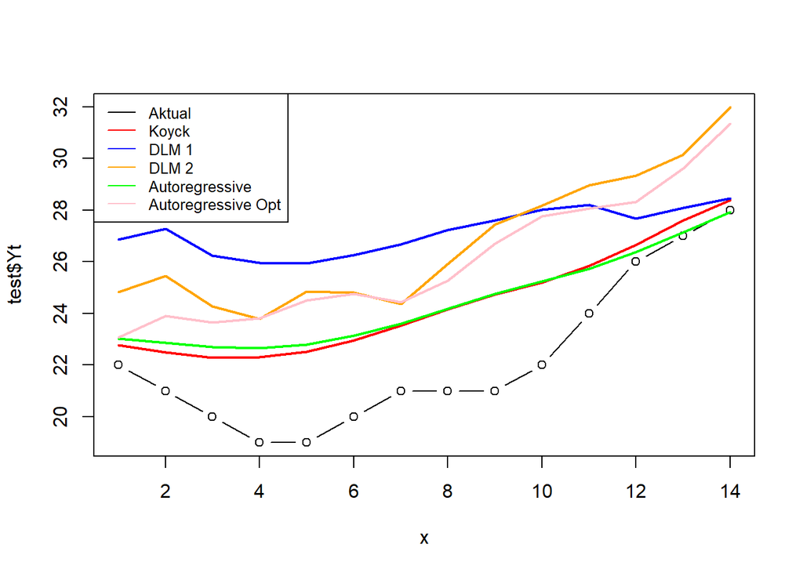

```r
x <- 1:length(test$Xt)  # buat x = 1,2,3,...,7

plot(x, test$Yt, type="b", col="black",
     ylim=range(c(test$Yt, fore.koyck$forecasts,
                  fore.dlm$forecasts, fore.dlm2$forecasts,
                  fore.ardl$forecasts)))

lines(x, fore.koyck$forecasts, col="red", lwd=2)
lines(x, fore.dlm$forecasts, col="blue", lwd=2)
lines(x, fore.dlm2$forecasts, col="orange", lwd=2)
lines(x, fore.ardl$forecasts, col="green", lwd=2)
lines(x, fore.ardl.opt$forecasts, col="pink", lwd=2)

legend("topleft",
       c("Aktual", "Koyck","DLM 1","DLM 2", "Autoregressive", "Autoregressive Opt"),
       lty=1, col=c("black","red","blue","orange","green", "pink"), cex=0.8)
```